# Assignment 2

Tal Waitzenberg & Lital Morali

### Introduction

In this model we have decided to explore the missing data, and to see if we can predict the missing data by the existing data and hope to get a better predictions about the survivals.

### data preproccessing

set working directory

```r
setwd('C:/Users/talon/Desktop/shitot/Assignment2')
#install.packages('knitr')
knitr::opts_knit$set(root.dir = 'C:/Users/talon/Desktop/shitot')
getwd()
```

read data csv files:

```r
library(ggplot2)
library(caret)
train.data <- read.csv("Titanic/train.csv",na.strings = "")
test.data <- read.csv("Titanic/test.csv",na.strings = "")
train.data.nrow<-seq(1, nrow(train.data))
```

Merge the data (merge test and train to predict both missing data together) * we added Survived column to test file because its no exsits there.

```r
merged.data <-rbind(train.data, cbind(test.data, Survived=rep(NA, nrow(test.data))))
```

### Variables Description:

| Feature | Description |
| --- | --- |
| survival | Survival (0 = No; 1 = Yes) |
| pclass | Passenger Class (1 = 1st; 2 = 2nd; 3 = 3rd) |
| name | Name |
| sex | Sex |
| age | Age |
| sibsp | Number of Siblings/Spouses Aboard |
| parch | Number of Parents/Children Aboard |
| ticket | Ticket Number |
| fare | Passenger Fare |
| cabin | Cabin |
| embarked | Port of Embarkation (C = Cherbourg; Q = Queenstown; S = Southampton) |

Now we check what are the missing data fields

```r
#install.packages('reshape')
library(reshape)
merged.data.missing <- melt(apply(merged.data[, -2], 2, function(x) sum(is.na(x) | x=="")))
knitr::kable(merged.data.missing,caption = "Missing data")
```

[output not shown]

```r
qplot(merged.data$Age, main="Passenger Age", xlab = "Age", bins = 30)
```

[output not shown]

```r
merged.data$Name_Abbreviations<-regmatches(as.character(merged.data$Name),regexpr("\\,[A-z ]{1,20}\\.", as.character(merged.data$Name)))
merged.data$Name_Abbreviations<-unlist(lapply(merged.data$Name_Abbreviations,FUN=function(x) substr(x, 3, nchar(x)-1)))
qplot(merged.data$Name_Abbreviations, main="Name honorific Abbreviations", xlab = "Abbreviations")
```

[output not shown]

```r
merged.data$Name_Abbreviations[which(merged.data$Name_Abbreviations %in% c("Mme", "Mlle"))] <- "Miss"
merged.data$Name_Abbreviations[which(merged.data$Name_Abbreviations %in% c("Lady", "Ms", "the Countess", "Dona"))] <- "Mrs"
merged.data$Name_Abbreviations[which(merged.data$Name_Abbreviations=="Dr" & merged.data$Sex=="female")] <- "Mrs"
merged.data$Name_Abbreviations[which(merged.data$Name_Abbreviations=="Dr" & merged.data$Sex=="male")] <- "Mr"
merged.data$Name_Abbreviations[which(merged.data$Name_Abbreviations %in% c("Capt", "Col", "Don", "Jonkheer", "Major", "Rev", "Sir"))] <- "Mr"
merged.data$Name_Abbreviations<-as.factor(merged.data$Name_Abbreviations)
```

Now according to new “Name_Abbreviations” variable lets fill all passengers with missing age according to their “Name_Abbreviations” group median age.

```r
age<-aggregate(merged.data$Age,by = list(merged.data$Name_Abbreviations), FUN = function(x) median(x, na.rm = T))
merged.data[is.na(merged.data$Age), "Age"] <- apply(merged.data[is.na(merged.data$Age), ] , 1, function(x) age[age[, 1]==x["Name_Abbreviations"], 2])
```

back to other missing data, There is 2 passengers with missing “Embarked”, lets check the most common

```r
table(merged.data$Embarked)
```

[output not shown]

```r
merged.data$Embarked[which(is.na(merged.data$Embarked) | merged.data$Embarked=="")] <- 'S'
```

Now lets split the data to test and train

```r
test.data <- merged.data[-train.data.nrow, ]
train.data <- merged.data[train.data.nrow, ]
```

lets train our model with caret package, we going to use random forest model

```r
set.seed(1234)
train.data$Survived<- as.factor(train.data$Survived)
train.data$Pclass<- as.factor(train.data$Pclass)
library('randomForest')
fit.rf <- train(Survived ~ Pclass+Age+SibSp+Parch+Name_Abbreviations, data=train.data, method="rf", ntree=2000, trControl=trainControl(method="cv", number=5), tuneGrid=expand.grid(.mtry=seq(1,7,1)))
```

create csv file to random forest model

```r
test.data$Pclass <- as.factor(test.data$Pclass)
fit.rf.pred<- predict(fit.rf,  newdata=test.data, type="raw")
res <- cbind(PassengerId = test.data$PassengerId,Survived=as.character(fit.rf.pred))
write.csv(res,file="Titanic/try1.csv",row.names = F)
```

[figure not shown]

We scored 0.77512 now lets try use linear reggression model “glm”, and lets add Embarked field to the model

```r
fit.glm <- glm(Survived ~ Pclass+Age+SibSp+Parch+Embarked+Name_Abbreviations, data=train.data, family=binomial)
fit.glm.pred<-predict(fit.glm,  newdata=test.data, type="response")
test.data$Survived <- as.numeric(as.numeric(fit.glm.pred)>0.5)
res <- cbind(PassengerId = test.data$PassengerId,Survived=as.numeric(as.numeric(fit.glm.pred)>0.5))
write.csv(res,"Titanic/try2.csv", row.names=F)
```

[figure not shown]

We scored 0.78469, which is an improvment. we got beeter result with linear reggression lets remove the Embarked field from the model, ans see if there is improvment in the results

```r
fit.glm_no_Embarked <- glm(Survived ~ Pclass+Age+SibSp+Parch+Name_Abbreviations, data=train.data, family=binomial)
fit.glm_no_Embarked.pred<-predict(fit.glm_no_Embarked,  newdata=test.data, type="response")
res <- cbind(PassengerId = test.data$PassengerId,Survived=as.numeric(as.numeric(fit.glm_no_Embarked.pred)>0.5))
write.csv(res,"Titanic/try3.csv", row.names=F)
```

We scored 0.79426, our best score.

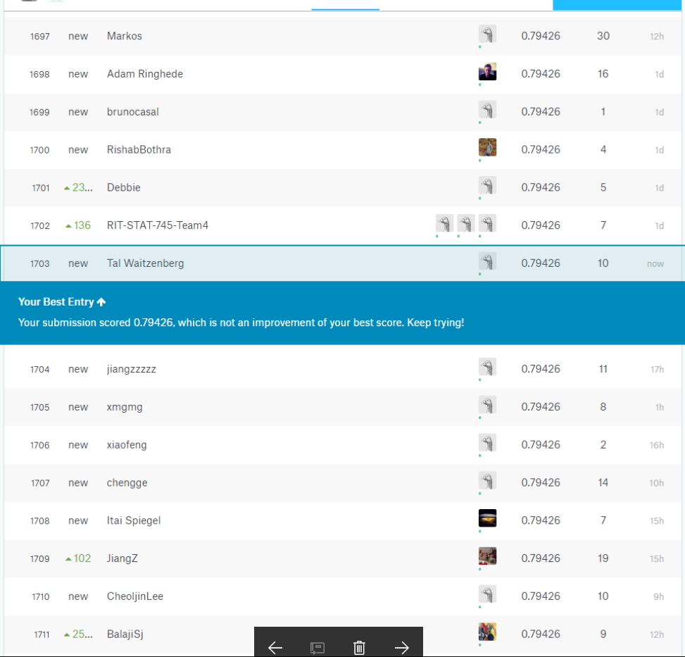